# AI & LLM Interview Questions

## Q1. Generative vs Discriminative Models

| Feature | Discriminative | Generative |
| --- | --- | --- |
| **Goal** | Learn boundary between classes | Learn distribution of data |
| **Learns** | P(Y\|X) — probability of label given input | P(X,Y) or P(X) — joint/data distribution |
| **Output** | Class label / decision | New data (text, image, audio) |
| **Training data** | Needs labeled data | Can be unsupervised or self-supervised |
| **Examples** | Logistic Regression, SVM, BERT (classifier), Random Forest | GPT, DALL-E, VAE, GAN, Stable Diffusion |
| **Use case** | Spam detection, sentiment, classification | Text generation, image synthesis, translation |

### Simple analogy

```
Discriminative:  Given a photo → is it a cat or dog? (draws a boundary)
Generative:      Given nothing → generate a photo of a cat (learns what a cat looks like)
```

### How Generative Models work (self-supervised)

```
GPT:   Input: "The cat sat on the ___"  → predict next token → learns language distribution
BERT:  Input: "The [MASK] sat on mat"  → predict masked token → learns context (discriminative backbone)
GAN:   Generator creates fake images → Discriminator tries to detect fake → both improve together
```

↑ Back to Index

## Q2. Tokens & Embeddings — How They Work Together

### Tokens

- A **token** is the smallest unit of text a model processes
- Not always a word — can be subword, character, or word piece
- Tokenizer converts raw text → sequence of integer IDs

```
Text:    "unhappiness"
Tokens:  ["un", "happiness"]        ← subword tokenization (BPE)
IDs:     [1045, 8398]

Text:    "Hello world!"
Tokens:  ["Hello", " world", "!"]   ← ~3 tokens
Rule of thumb: 1 token ≈ 0.75 words ≈ 4 characters (English)
```

### Tokenization algorithms

| Algorithm | Used by | How | Package |
| --- | --- | --- | --- |
| BPE (Byte Pair Encoding) | GPT-2, GPT-4, Llama | Merge most frequent pairs iteratively | from tokenizers import Tokenizer |
| WordPiece | BERT | Similar to BPE but maximizes language model likelihood | from transformers import AutoTokenizer |
| SentencePiece | T5, Gemini | Language-agnostic subword, works on raw text | import sentencepiece as spm |
| Tiktoken | GPT-3.5/4 (OpenAI) | Faster BPE implementation | import tiktoken |

### Embeddings

- An **embedding** is a dense vector of floats representing a token (or sentence) in high-dimensional space
- Similar meanings → vectors close together (small cosine distance)
- Token IDs → looked up in an **embedding matrix** → vector of size `d_model` (e.g. 768, 1536, 4096)

```
Embedding matrix shape: [vocab_size × d_model]
e.g. GPT-2: [50257 × 768]

token_id = 1045  →  lookup row 1045  →  [0.23, -0.11, 0.87, ..., 0.04]  (768 floats)
```

### How they work together

```
Raw text
   ↓  Tokenizer
Token IDs:   [9906, 1917, 0]          ("Hello", " world", "!")
   ↓  Embedding lookup
Vectors:     [[0.2, -0.1, ...],       (each token → 768-dim vector)
              [0.5,  0.3, ...],
              [-0.1, 0.9, ...]]
   ↓  + Positional Encoding
Input to Transformer
```

### Why embeddings capture meaning

```
king  - man + woman ≈ queen        (famous word2vec analogy)
Paris - France + Italy ≈ Rome      (semantic arithmetic works in vector space)
```

↑ Back to Index

## Q6. Types of Chunking

Chunking = splitting documents into pieces before embedding. **The most important RAG decision.**

| Type | How | Advantage | Disadvantage | When to use |
| --- | --- | --- | --- | --- |
| **Fixed size** | Split every N characters/tokens (500 tokens+overlap) | Simple, fast, predictable | Can split mid-sentence, breaks context | Baseline; uniform text |
| **Recursive Sentence** | Split at sentence boundaries | Preserves sentence meaning | Sentences vary in size; short = low context | FAQ, short factual docs |
| **Recursive Paragraph** | Split at paragraph/double newline | Natural topic boundary | Paragraphs vary widely in size | Articles, reports |
| **Recursive** | Try separators in order: `\n\n` → `\n` → `.` → → char | Respects structure, flexible | More complex | General purpose (LangChain default) |
| **Semantic (with meaning)** | Split where embedding similarity drops (topic shift) | Semantically coherent chunks | Slow; needs embedding every sentence,expensive | Long mixed-topic docs |
| **Document structure** | Split by headings, sections (HTML tags, Markdown headers) | Preserves document structure | Format-specific | PDFs, Markdown, HTML docs |
| **Agentic / Propositions** | LLM rewrites doc into atomic factual statements | Very high retrieval precision | Expensive (LLM call per doc) | High-accuracy RAG systems |
| **contextial retreval** | context+ chunk | better | Format-specific | cosyly |

heirarchical

```
from langchain_text_splitters import RecursiveCharacterTextSplitter

splitter = RecursiveCharacterTextSplitter(
    chunk_size=500,
    chunk_overlap=50
)

chunks = splitter.split_text(text)



from langchain_experimental.text_splitter import SemanticChunker

splitter = SemanticChunker(embeddings)
```

Best for:

- RAG
- Knowledge bases
- Long documents

### Chunk size trade-off

```
Small chunks (128–256 tokens):
  + Precise retrieval (matches narrow query well)
  - Missing context (answer may span multiple chunks)

Large chunks (512–1024 tokens):
  + More context per chunk
  - Noisy retrieval (relevant part buried in chunk)
  - Fewer chunks fit in LLM context window

Overlap (e.g. 20% overlap between chunks):
  → Prevents answer from falling at chunk boundary
  → Common: chunk_size=512, overlap=50
```

### How to choose

```
Short Q&A / FAQs           → Sentence or small fixed (256 tokens)
Technical docs / manuals   → Recursive or document structure
Long research papers       → Semantic or paragraph with overlap
Legal / contracts          → Document structure (sections/clauses)
High accuracy required     → Agentic / proposition chunking
```

↑ Back to Index

## Q7. Types of Embeddings

| Type | What it embeds | Example models | Use case |
| --- | --- | --- | --- |
| **Word embeddings** | Single words | Word2Vec, GloVe, FastText | Classic NLP, word similarity |
| **Sentence embeddings** | Full sentence/passage | SBERT, E5, BGE, GTE | Semantic search, RAG, clustering |
| **Document embeddings** | Long documents | Longformer, Doc2Vec | Document similarity, classification |
| **Cross-encoder** | Pair (query, doc) → relevance score | BERT fine-tuned | Re-ranking retrieved results |
| **Multi-modal embeddings** | Text + image together | CLIP, ImageBind | Image-text search |
| **Code embeddings** | Source code | CodeBERT, StarCoder embeddings | Code search, similarity |
| **Sparse embeddings** | TF-IDF style weighted word vectors | SPLADE, BM25 | Lexical keyword search |
| **Dense embeddings** | Continuous vector, meaning-based | text-embedding-3, E5-large | Semantic similarity |

### Dense vs Sparse

```
Dense:   [0.23, -0.11, 0.87, 0.04, ...]   1536 non-zero floats
         Captures semantic meaning (synonyms match)
         "car" ≈ "automobile"  → close in dense space

Sparse:  [0, 0, 0, 3.2, 0, 0, 1.1, 0, ...]  mostly zeros
         Captures exact keyword match (like BM25/TF-IDF)
         "car" ≠ "automobile"  unless both in query

Hybrid:  Dense + Sparse combined → best of both (Weaviate, Pinecone hybrid search)
```

### Bi-encoder vs Cross-encoder

```
Bi-encoder (e.g. SBERT):
  Embed query and doc independently → compare with cosine similarity
  Fast — pre-compute doc embeddings → O(1) lookup
  Use for: retrieval (first stage)

Cross-encoder (e.g. fine-tuned BERT):
  Takes [query + doc] together → outputs relevance score 0-1
  Accurate — attends across both — but slow (can't pre-compute)
  Use for: re-ranking top-K retrieved results (second stage)

RAG pipeline:  Bi-encoder retrieval → Cross-encoder re-ranking → LLM
```

### Popular embedding models (2024-2025)

[output not shown]

↑ Back to Index

## Q3. Transformer Architecture — Attention Is All You Need

### Why Transformers are powerful

```
1. Parallelism     → process all tokens at once (not sequential like RNN)
2. Long range      → any token can attend to any other in O(1) steps
3. Scalable        → more layers + more heads + bigger FFN = better
4. Transfer learn  → pre-train once on huge data, fine-tune for anything
5. Attention maps  → interpretable — can see what the model focuses on
```

### Encoder vs Decoder vs Encoder-Decoder

| Architecture | Models | Use case |
| --- | --- | --- |
| Encoder only | BERT, RoBERTa | Classification, embeddings, understanding |
| Decoder only | GPT, Llama, Claude | Text generation, completion |
| Encoder-Decoder | T5, BART, mT5 | Translation, summarization, Q&A |

| Feature | GPT | BERT |
| --- | --- | --- |
| **Full Form** | Generative Pre-trained Transformer | Bidirectional Encoder Representations from Transformers |
| **Architecture** | Decoder-only Transformer | Encoder-only Transformer |
| **Main Purpose** | Generate text | Understand text |
| **Attention** | Causal (left-to-right) | Bidirectional |
| **Training Objective** | Predict the next token | Masked Language Modeling (MLM) |
| **Best For** | Chatbots, content generation, coding, summarization | Search, classification, semantic similarity, embeddings |
| **Output** | Generates new text | Produces contextual representations/embeddings |
| **Used in RAG** | Generator (LLM that produces the final answer) | Retriever, reranker, or embedding model |
| **Context Visibility** | Can only see previous tokens | Can see both previous and future tokens |
| **Example Models** | GPT-3, GPT-4, GPT-4o | BERT, RoBERTa, DistilBERT, SBERT |
| **Primary Use Cases** | Text generation, code generation, Q&A, translation | Sentiment analysis, NER, search, document retrieval |
| **Inference Style** | Autoregressive (token-by-token generation) | Encodes the entire input simultaneously |
| **Strength** | Fluent text generation and reasoning | Deep language understanding and semantic representation |
| **Limitation** | Not optimized purely for retrieval/classification | Cannot naturally generate long-form text |

# Interview Summary

**Self-Attention**

- Q, K, and V come from the same sequence.
- Learns relationships within a sentence.
- Used in GPT and BERT.

**Cross-Attention**

- Q comes from one sequence, K and V come from another.
- Connects information between two sequences.
- Used in encoder-decoder models like T5 and BART.

### Easy way to remember

- **Self-Attention:** "I am looking at myself."
- **Cross-Attention:** "I am looking at another sequence."

# Self-Attention vs Cross-Attention

| Feature | Self-Attention | Cross-Attention |
| --- | --- | --- |
| **Definition** | Tokens attend to other tokens within the **same sequence** | Tokens attend to tokens from **another sequence** |
| **Query (Q)** | Comes from the current sequence | Comes from the decoder/current sequence |
| **Key (K)** | Comes from the same sequence | Comes from the encoder/another sequence |
| **Value (V)** | Comes from the same sequence | Comes from the encoder/another sequence |
| **Used In** | Transformer Encoder, GPT Decoder, BERT | Encoder-Decoder models like T5, BART, original Transformer |
| **Purpose** | Learn relationships within a sentence | Connect information between two different sequences |
| **Example** | Understanding context within a sentence | Translating English to French or attending to retrieved documents |

↑ Back to Index

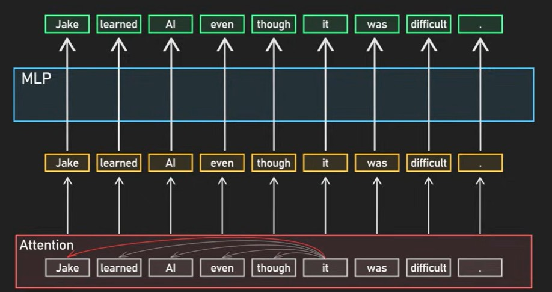

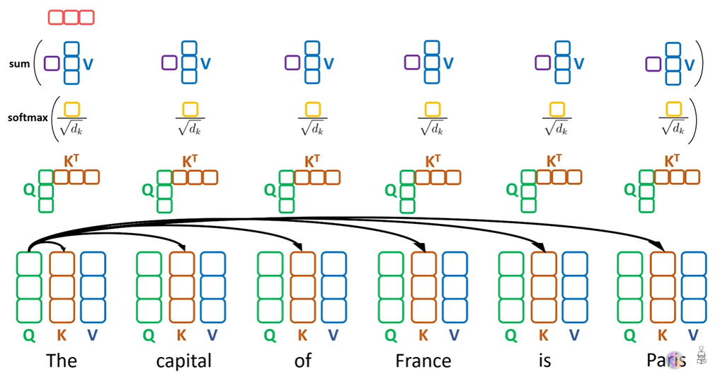

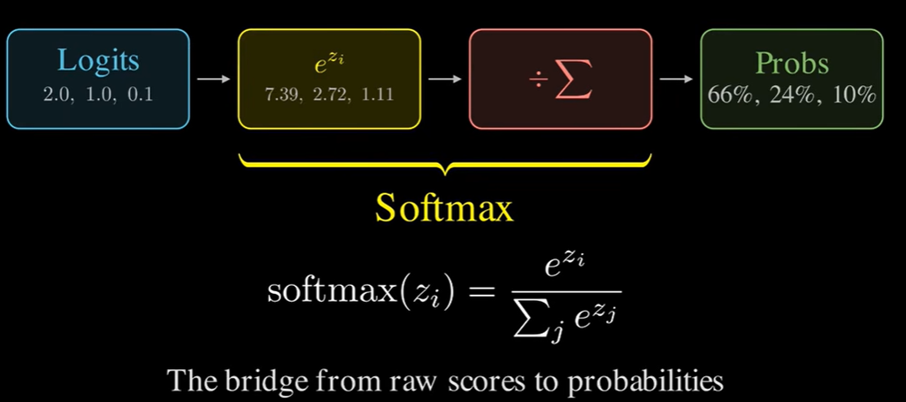

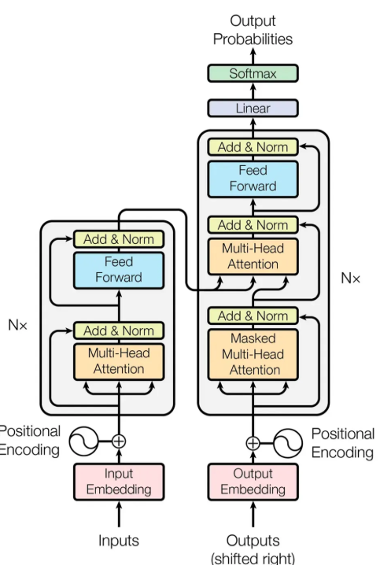

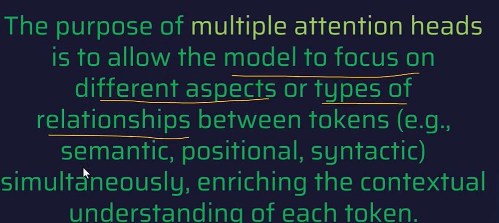

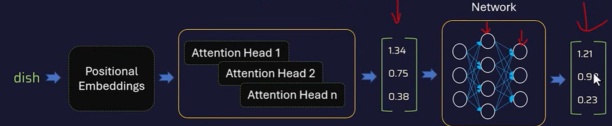

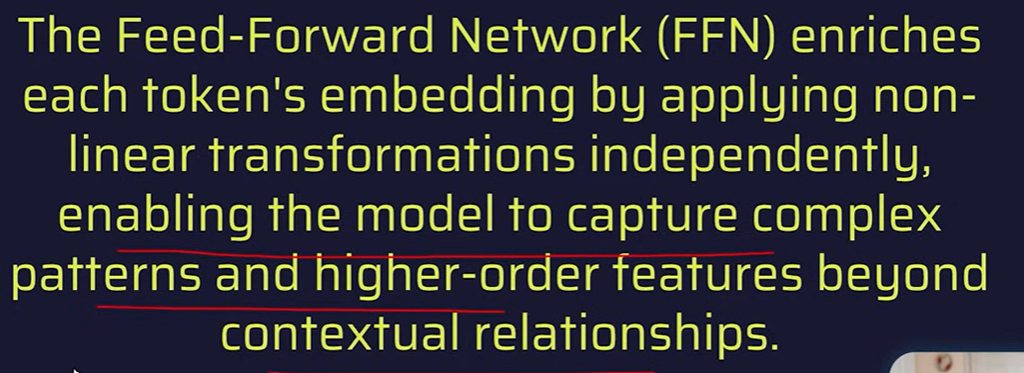

## Q4. Top-K, Top-P & Temperature

These control **how the model samples the next token** from the probability distribution.

### Temperature --- logit->scale the logit by temp values - soft max with /T

```
Scales the logits before softmax:
  P(token) = softmax(logits / temperature)

Temperature = 1.0  → original distribution (default)
Temperature < 1.0  → sharper distribution → more confident → more deterministic / repetitive
Temperature > 1.0  → flatter distribution → more uniform → more random / creative
Temperature → 0    → always picks highest probability token (greedy decoding)
```

### Top-K

```
Keep only the K highest probability tokens, set rest to 0, renormalize.

Top-K = 3:
  Full vocab: [cat:0.5, dog:0.3, car:0.1, tree:0.05, ...]
  After Top-3: [cat:0.5, dog:0.3, car:0.1] → renormalize → sample from these 3 only

Problem: K=50 might include irrelevant tokens when dist is sharp,
         or exclude good tokens when dist is flat.
```

### Top-P (Nucleus Sampling)

```
Keep the smallest set of tokens whose cumulative probability ≥ P.

Top-P = 0.9:
  Sort by prob:  cat:0.5, dog:0.3, car:0.1, tree:0.06, ...
  Cumulative:    0.5 → 0.8 → 0.9  ← stop here
  Nucleus:       [cat, dog, car] → renormalize → sample

Advantage: dynamic — adapts to sharp (few tokens) or flat (many tokens) distributions
```

### Comparison

| Parameter | Controls | Range | Low value | High value |
| --- | --- | --- | --- | --- |
| **Temperature** | Sharpness of distribution | 0 → ∞ | Deterministic, repetitive | Random, creative |
| **Top-K** | Fixed number of candidates | 1 → vocab_size | Focused (top 1 = greedy) | More variety |
| **Top-P** | Dynamic probability mass | 0 → 1 | Fewer candidates | More candidates |

### Typical settings

```
Factual / coding tasks:    temperature=0.2, top_p=0.9   (focused, accurate)
General chat:              temperature=0.7, top_p=0.95  (balanced)
Creative writing:          temperature=1.2, top_p=0.95  (diverse, surprising)
Deterministic/debug:       temperature=0,  top_k=1      (greedy — same output every time)
```

↑ Back to Index

## Q5. RAG Architecture (Retrieval-Augmented Generation)

### Problem RAG solves

```
LLMs have a knowledge cutoff and can hallucinate.
RAG = give the LLM relevant external documents at query time → grounded answers.
```

### Full RAG Architecture

```
INDEXING PIPELINE (offline — done once)
────────────────────────────────────────
Documents (PDF, web, DB)
   ↓  Chunking
Text chunks (e.g. 512 tokens each)
   ↓  Embedding model (e.g. text-embedding-3-small)
Dense vectors  [0.23, -0.11, ..., 0.87]  (1536-dim)
   ↓  Store
Vector Database (Pinecone, Weaviate, ChromaDB, FAISS)


QUERY PIPELINE (online — per user question)
────────────────────────────────────────────
User query: "What is our refund policy?"
   ↓  Same embedding model
Query vector
   ↓  ANN search in vector DB (top-K similar chunks)
Retrieved chunks (e.g. top 5 most similar)
   ↓  Prompt construction
Prompt: "Context: [chunk1][chunk2]...  Question: What is our refund policy?"
   ↓  LLM (GPT-4, Claude, Llama)
Answer grounded in retrieved documents
```

### RAG variants

| Type | Description | When to use |
| --- | --- | --- |
| **Naive RAG** | Basic retrieve → generate | Simple Q&A |
| **Advanced RAG** | Re-ranking, query rewriting, HyDE | Better accuracy needed |
| **Modular RAG** | Plug-in components (router, fusion, summarizer) | Complex pipelines |
| **Agentic RAG** | LLM decides when/what to retrieve | Multi-hop, tool-use |
| **Graph RAG** | Knowledge graph + vector retrieval | Relational/structured knowledge |

### Key components to optimize

```
1. Chunking strategy    → chunk size + overlap affects retrieval quality
2. Embedding model      → must match domain; same model for index + query
3. Retrieval (top-K)    → too few = miss info; too many = noise in context
4. Re-ranking           → cross-encoder scores retrieved chunks for relevance
5. Context window       → fit retrieved chunks + query into LLM context limit
6. Prompt template      → how context is presented to LLM matters
```

## rag types:

```
Standard RAG – Retrieve once and generate.
Hybrid RAG – Combine dense vector search with keyword search.
Corrective RAG (CRAG) – Validate and improve retrieved results before answering.
Self-RAG – The model decides whether it needs more retrieval and critiques its own output.
Agentic RAG / ReAct – The model plans, retrieves, reasons, and may use tools in multiple steps.
RAPTOR / Hierarchical RAG – Organize documents into hierarchical summaries for scalable retrieval.
Fusion and Multi-Source RAG – Aggregate information from multiple retrievers or data sources for better coverage.
```

↑ Back to Index

## Q8. Vector DB Architecture — How Data is Stored

### What is a Vector DB?

A database optimized for storing and querying high-dimensional vectors using **Approximate Nearest Neighbor (ANN)** search.

### How data is stored

```
Each record = { id, vector, metadata }

id:        "doc_001"
vector:    [0.23, -0.11, 0.87, ..., 0.04]   (1536 floats = ~6KB)
metadata:  {"source": "manual.pdf", "page": 5, "chunk": "Returns policy..."}

Storage layers:
  1. Vector store    → flat files or segments (like SSTable) with float arrays
  2. Index structure → HNSW graph or IVF clusters for fast search
  3. Metadata store  → separate KV store or column store for filtering
  4. WAL / log       → durability (write-ahead log)
```

### Core operations

```
INSERT:  embed text → store (id, vector, metadata)
SEARCH:  embed query → find top-K nearest vectors (cosine/dot/L2)
FILTER:  metadata filter first → then ANN search on subset (pre-filter or post-filter)
DELETE:  mark vector as deleted; compaction removes it
UPDATE:  delete + re-insert (vectors are immutable)
```

### Distance metrics

| Metric | Formula (simplified) | Best for |
| --- | --- | --- |
| **Cosine similarity** | angle between vectors | Text (direction matters, not magnitude) |
| **Dot product** | magnitude × cosine | Normalized vectors (same as cosine if unit vectors) |
| **Euclidean (L2)** | straight-line distance | Image embeddings, absolute position matters |

### Popular Vector DBs

| DB | Index | Hosted | Notes |
| --- | --- | --- | --- |
| Pinecone | HNSW + IVF | ✅ Managed | Production-ready, easy API |
| Weaviate | HNSW | Both | Hybrid search, GraphQL |
| Qdrant | HNSW | Both | Fast, Rust, filtering |
| ChromaDB | HNSW | Self-hosted | Local dev, LangChain default |
| FAISS | IVF, HNSW, PQ | Library | Meta, high performance, no server |
| pgvector | IVFFlat, HNSW | PostgreSQL ext | SQL + vectors together |
| Milvus | IVF, HNSW | Both | Large scale, enterprise |

↑ Back to Index

## Q9. Vector DB Index Types

### Why indexing?

```
Brute-force search: compare query to every vector → O(n × d) → too slow at scale
ANN index:          approximate search → O(log n) or O(√n) → 99% accuracy, 1000× faster
```

### Index Types

#### 1. Flat (Brute Force)

```
No index — compute exact similarity to every vector.
Accuracy: 100% (exact)
Speed:    Slow (O(n))
Use when: < 10K vectors, accuracy critical, testing/debug
```

#### 2. IVF — Inverted File Index

```
Step 1: Cluster vectors into K centroids (K-means)
Step 2: At query time, find nearest centroid(s)
Step 3: Search only vectors in those cluster(s)

nlist   = number of clusters (e.g. 100)
nprobe  = how many clusters to search (higher = more accurate, slower)

Accuracy: Good (tunable with nprobe)
Speed:    Fast (only search subset)
Use when: 100K – 10M vectors, batch indexing OK
```

#### 3. HNSW — Hierarchical Navigable Small World (like skip list)

```
Builds a multi-layer graph:
  Layer 2 (top):   few nodes, long-range connections   → coarse navigation
  Layer 1 (mid):   more nodes, medium connections
  Layer 0 (base):  all nodes, short-range connections  → fine search

Query: start at top layer → greedy walk toward query → descend layers → find neighbors

M    = max connections per node (higher = better accuracy, more memory)
efC  = construction beam width (higher = better index, slower build)
efS  = search beam width (higher = better recall, slower search)

Accuracy: Very high (>99% recall)
Speed:    Very fast (log n)
Memory:   High (stores the graph)
Use when: < 10M vectors, low-latency needed (default in Pinecone, Weaviate, Qdrant)
```

#### 4. PQ — Product Quantization

```
Compress vectors: split 1536-dim vector into M subvectors → quantize each to 256 codes
1536 floats × 4 bytes = 6KB per vector  →  M bytes per vector (8-32× compression)

Accuracy: Lower (lossy compression)
Memory:   Very low
Use when: Billions of vectors, memory constrained
Often combined: IVF+PQ (FAISS default for large scale)
```

#### 5. LSH — Locality Sensitive Hashing

```
Hash similar vectors into same bucket using random projections.
Query = hash → lookup bucket → compare within bucket only.

Accuracy: Lower
Speed:    Very fast
Use when: Very high throughput, some accuracy loss acceptable
```

### Summary

| Index | Accuracy | Speed | Memory | Scale |
| --- | --- | --- | --- | --- |
| Flat | 100% | Slowest | Low | <10K |
| IVF | High | Fast | Medium | 100K–10M |
| HNSW | Very high | Very fast | High | <10M |
| IVF+PQ | Medium | Fast | Very low | 10M–1B |
| LSH | Medium | Fastest | Low | High throughput |

Annoy ann oh yeah from spotify (randomforest)

↑ Back to Index

## Q10. Fine-tuning, PEFT, BERT, LoRA, QLoRA, Adapters

### Full Fine-tuning

```
Take a pre-trained LLM → update ALL parameters on your task-specific data.

Problem:
  GPT-3:   175B parameters × 4 bytes = 700 GB  → needs multiple A100 GPUs
  LLaMA-2: 70B parameters             → needs ~140 GB GPU memory
  Expensive, slow, risk of catastrophic forgetting.
```

### PEFT — Parameter Efficient Fine-Tuning

```
Why introduced:
  Full fine-tune is too expensive for most use cases.
  PEFT: freeze most of the model → only train a small number of new/modified parameters.
  Result: similar performance to full fine-tune at 0.1–1% of the compute cost.

Full fine-tune: update 100% of parameters
PEFT:           update 0.1–5% of parameters
```

### BERT

```
BERT = Bidirectional Encoder Representations from Transformers (Google, 2018)
Architecture: Encoder-only Transformer
Training:     Masked Language Modeling (MLM) + Next Sentence Prediction (NSP)
Reads text:   bidirectionally (sees left AND right context simultaneously)

Use cases: Classification, NER, QA, embeddings — NOT text generation
Fine-tuning: Add task-specific head on top of [CLS] token → train whole model

BERT-base:  12 layers, 110M params
BERT-large: 24 layers, 340M params
```

### LoRA — Low Rank Adaptation

```
Key insight: weight updates during fine-tuning have low intrinsic rank.
             → approximate ΔW with two small matrices instead of full matrix.

Original weight matrix W: shape [d × k]  (e.g. 4096 × 4096 = 16M params)
LoRA: freeze W, add   W + ΔW = W + B × A
      A: shape [r × k]  (r << d,  e.g. r=8)
      B: shape [d × r]
      Trainable params = d×r + r×k  (e.g. 4096×8 + 8×4096 = 65K  vs  16M)

LoRA rank r:
  r=4–8:   lightweight, good for style/tone changes
  r=16–32: better for domain adaptation
  r=64+:   approaches full fine-tune quality

WHERE in LLM:
  Applied to Transformer attention weight matrices:
  Q (query), K (key), V (value), and output projection Wₒ
  Sometimes also FFN (feed-forward) layers
  Stage: during fine-tuning (after pre-training), not during pre-training

At inference: merge B×A back into W → zero extra latency
```

### QLoRA — Quantized LoRA

```
LoRA + Quantization of the base model weights.

Base model: quantized to 4-bit (NF4 — NormalFloat4) → 4× memory reduction
LoRA adapters: kept in 16-bit (bfloat16) → still trainable

Result:
  LLaMA-2-70B full fine-tune: ~140 GB GPU
  QLoRA on same model:        ~48 GB GPU  (fits on 2× A100 40GB)

Key techniques in QLoRA:
  1. NF4 quantization     → optimal for normally distributed weights
  2. Double quantization  → quantize the quantization constants too (saves ~0.4 bits/param)
  3. Paged optimizers     → offload optimizer states to CPU RAM to prevent OOM
```

### Adapters

```
Insert small trainable modules (bottleneck layers) between Transformer layers.
Freeze original model → only adapter layers trained.

Structure of one adapter:
  Input (d) → Linear down (d → m) → GELU → Linear up (m → d) → + residual → Output (d)
  m << d  (bottleneck, e.g. d=768, m=64)

Difference from LoRA:
  Adapters:  add new layers between existing layers → small inference overhead
  LoRA:      modifies existing weight matrices directly → zero inference overhead (after merge)

LoRA is generally preferred today (faster inference, equally efficient training).
```

### Summary Table

| Method | Params trained | Memory | Inference overhead | Best for |
| --- | --- | --- | --- | --- |
| Full fine-tune | 100% | Very high | None | Best accuracy, have compute |
| Adapter | ~1–3% (new layers) | Low | Small (extra layers) | Task-specific add-ons |
| LoRA | ~0.1–1% (low-rank) | Low | None (merged) | General PEFT, most popular |
| QLoRA | ~0.1–1% (4-bit base) | Very low | None (merged) | Consumer GPU, large models |
| Prompt tuning | Soft prompt tokens only | Minimal | Tiny | Simple task adaptation |

### Where LoRA fits in the LLM lifecycle

```
Stage 1: Pre-training       → Train on trillion tokens from internet (full training)
                               Result: base model (e.g. LLaMA-3-base)

Stage 2: SFT with LoRA      → Fine-tune on instruction/task data (LoRA applied here)
                               Result: instruction-following model

Stage 3: RLHF / DPO + LoRA → Align with human preferences (LoRA applied here too)
                               Result: chat model (e.g. LLaMA-3-instruct)

Stage 4: Domain fine-tune   → Company-specific data (LoRA / QLoRA)
                               Result: domain-specific assistant

LoRA is used at Stages 2, 3, 4 — never during pre-training (Stage 1).
```

↑ Back to Index

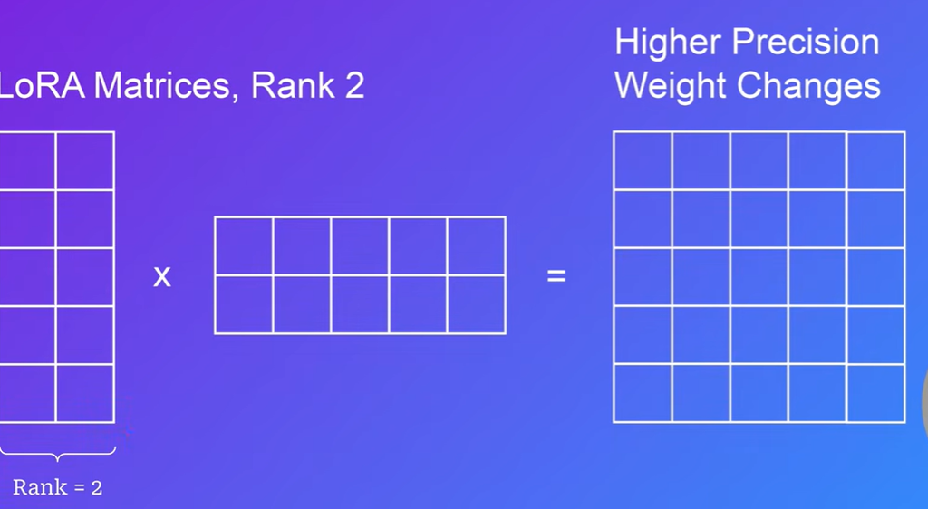

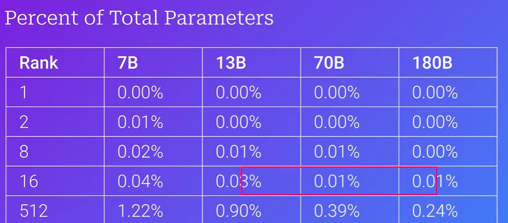

# LoRA vs QLoRA

**LoRA (Low-Rank Adaptation)** and **QLoRA (Quantized Low-Rank Adaptation)** are **Parameter-Efficient Fine-Tuning (PEFT)** techniques that allow you to fine-tune Large Language Models (LLMs) without updating all model parameters.

The main difference is that **QLoRA loads the base model in quantized form (4-bit)**, significantly reducing GPU memory usage.

## Comparison Table

| Feature | LoRA | QLoRA |
| --- | --- | --- |
| Full Form | Low-Rank Adaptation | Quantized Low-Rank Adaptation |
| Base Model | FP16/BF16 | 4-bit Quantized |
| Train Base Model? | ❌ Frozen | ❌ Frozen |
| Trainable Parameters | Only LoRA adapters | Only LoRA adapters |
| GPU Memory | Higher | Much Lower |
| Quantization | No | Yes (4-bit NF4) |
| Training Speed | Fast | Slightly slower due to dequantization |
| Memory Efficiency | Good | Excellent |
| Accuracy | High | Nearly identical to LoRA in many tasks |
| Best For | Medium-sized models | Very large models on limited GPUs |

```
ΔW = A × B
```

where:

- `A` is a low-rank matrix
- `B` is a low-rank matrix

Only **A and B are trained**.

Final weight:

```
W' = W + A × B
```

```
Full Fine-Tuning
      │
      ▼
    LoRA
(Frozen Model + Adapters)
      │
      ▼
   QLoRA
(4-bit Frozen Model + Adapters)
```

```
from peft import LoraConfig
```

For QLoRA:

```
from transformers import BitsAndBytesConfig

bnb_config = BitsAndBytesConfig(
    load_in_4bit=True
)
```

# Q11. NVIDIA GPU Architectures (Ampere, Ada, Hopper, Blackwell)

## NVIDIA GPU Architecture Timeline

| Architecture | Release | Example GPUs | Key AI Features | Primary Use |
| --- | --- | --- | --- | --- |
| **Ampere** | 2020 | A100, A30, RTX 3090 | 3rd Gen Tensor Cores, TF32, BF16, MIG | AI training, HPC |
| **Ada Lovelace** | 2022 | RTX 4090, RTX 4080 | 4th Gen Tensor Cores, DLSS 3 | Gaming, AI inference |
| **Hopper** | 2022 | H100, H200 | Transformer Engine, FP8 | LLM training & inference |
| **Blackwell** | 2024 | B100, B200, GB200 | 2nd Gen Transformer Engine, FP4/FP8, NVLink improvements | Large-scale AI training and inference |

## What is CUDA?

**CUDA (Compute Unified Device Architecture)** is NVIDIA's parallel computing platform and programming model that enables developers to use NVIDIA GPUs for **general-purpose computing**, not just graphics rendering.

It allows thousands of threads to execute simultaneously, making GPUs ideal for:

- Deep Learning
- Machine Learning
- Large Language Models (LLMs)
- Scientific Computing
- Computer Vision
- High Performance Computing (HPC)

## High-Level NVIDIA GPU Architecture

```
                    CPU
                     │
             PCIe / NVLink
                     │
                     ▼
          +----------------------+
          |      NVIDIA GPU      |
          +----------------------+
                     │
     ┌───────────────┼────────────────┐
     │               │                │
     ▼               ▼                ▼
+---------+     +---------+     +---------+
|   SM 1  |     |   SM 2  | ... |  SM N   |
+---------+     +---------+     +---------+
     │               │                │
     ▼               ▼                ▼
 CUDA Cores     Tensor Cores     RT Cores
     │               │
     └─────── Shared Memory ───────┘
                     │
                     ▼
                L2 Cache
                     │
                     ▼
          Global GPU Memory (HBM/GDDR)
```

## NVIDIA GPU Architecture Components

| Component | Description | Primary Function | Example |
| --- | --- | --- | --- |
| **Streaming Multiprocessor (SM)** | Main processing unit containing CUDA Cores, Tensor Cores, registers, and shared memory | Executes thread blocks | H100 contains many SMs running in parallel |
| **CUDA Cores** | General-purpose parallel processing cores | Perform arithmetic and logical operations | Vector addition, matrix multiplication |
| **Tensor Cores** | Specialized AI acceleration units | Accelerate matrix multiplication for deep learning | Transformer training, LLM inference |
| **RT (Ray Tracing) Cores** | Dedicated hardware for ray tracing | Accelerate lighting, reflections, and shadows | Gaming and 3D rendering |
| **Warp** | Group of **32 threads** executed together | Basic scheduling unit of GPU execution | One warp = 32 parallel threads |
| **Thread Block** | Collection of one or more warps | Shares resources such as shared memory and executes on one SM | 256 threads = 8 warps |
| **Grid** | Collection of thread blocks launched by a CUDA kernel | Organizes the complete GPU workload | A kernel launching 100 blocks |
| **Memory Hierarchy** | Registers → Shared Memory → L1 Cache → L2 Cache → Global Memory | Provides different storage levels with varying speed and capacity | Shared Memory for fast communication between threads |

## CUDA Execution Hierarchy

```
CUDA Kernel
      │
      ▼
    Grid
      │
      ▼
Thread Blocks
      │
      ▼
    Warps
 (32 Threads)
      │
      ▼
Streaming Multiprocessor (SM)
      │
 ┌────┴───────────────┐
 │                    │
 ▼                    ▼
CUDA Cores      Tensor Cores
      │
      ▼
Memory Hierarchy
(Registers → Shared → L1 → L2 → Global)
```

## Memory Hierarchy

| Memory Type | Scope | Speed | Size | Purpose |
| --- | --- | --- | --- | --- |
| **Registers** | Per Thread | Fastest | Small | Store local variables |
| **Shared Memory** | Per Block | Very Fast | Medium | Share data among threads in a block |
| **L1 Cache** | Per SM | Fast | Small | Cache frequently accessed data |
| **L2 Cache** | Entire GPU | Moderate | Larger | Shared cache across SMs |
| **Global Memory (HBM/GDDR)** | Entire GPU | Slowest | Largest | Main storage for model weights and tensors |

## CUDA Programming Hierarchy

```
Kernel
   │
   ▼
Grid
   │
   ▼
Blocks
   │
   ▼
Warps (32 Threads)
   │
   ▼
Threads
   │
   ▼
CUDA Cores / Tensor Cores
```

# Why Choose `cuda:0`, `cuda:1`, `cuda:2` When Running an LLM? Pytorch

When a machine has **multiple NVIDIA GPUs**, each GPU is assigned an index:

| Device | Meaning |
| --- | --- |
| `cuda:0` | First GPU |
| `cuda:1` | Second GPU |
| `cuda:2` | Third GPU |
| `cuda:3` | Fourth GPU |
| ... | Additional GPUs |

# Bonus: GPU Architecture & CUDA

## NVIDIA GPU Architecture Components

| Component | Description | Primary Function |
| --- | --- | --- |
| **Streaming Multiprocessor (SM)** | Main processing unit containing CUDA Cores, Tensor Cores, registers, and shared memory | Executes thread blocks |
| **CUDA Cores** | General-purpose parallel processing cores | Arithmetic and logical operations |
| **Tensor Cores** | Specialized AI acceleration units | Matrix multiplication for deep learning (transformer training, LLM inference) |
| **Warp** | Group of **32 threads** executed together | Basic scheduling unit of GPU execution |
| **Thread Block** | Collection of one or more warps | Shares resources such as shared memory; executes on one SM |
| **Grid** | Collection of thread blocks launched by a CUDA kernel | Organizes the complete GPU workload |

## CUDA Execution Hierarchy

```
Kernel → Grid → Thread Blocks → Warps (32 Threads) → SM → CUDA / Tensor Cores
                                                          → Memory (Registers → Shared → L1 → L2 → Global)
```

## Memory Hierarchy

| Memory Type | Scope | Speed | Purpose |
| --- | --- | --- | --- |
| **Registers** | Per Thread | Fastest | Local variables |
| **Shared Memory** | Per Block | Very Fast | Share data among threads in a block |
| **L1 Cache** | Per SM | Fast | Cache frequently accessed data |
| **L2 Cache** | Entire GPU | Moderate | Shared cache across SMs |
| **Global Memory (HBM/GDDR)** | Entire GPU | Slowest | Main storage for model weights and tensors |

## Multi-GPU: cuda:0, cuda:1, cuda:2 (PyTorch)

```
# Each GPU gets an index
import torch
device = torch.device('cuda:0')   # First GPU
model = model.to('cuda:0')        # Load model onto GPU 0

# Distribute large model across GPUs
# LLaMA-70B won't fit in one GPU → split across cuda:0, cuda:1, cuda:2...
# Libraries: DeepSpeed, Accelerate, tensor_parallel
```

↑ Back to Index

# High-Level Architecture

```
                        User
                          │
                          ▼
                   Chatbot Interface
                          │
                          ▼
                    Query Processor
                          │
         ┌────────────────┴────────────────┐
         │                                 │
         ▼                                 ▼
   Intent Detection                Embedding Generation
         │                                 │
         └──────────────┬──────────────────┘
                        ▼
               Data Mart Router
                        │
      ┌─────────────────┼──────────────────┐
      │                 │                  │
      ▼                 ▼                  ▼
 Sales Mart       HR Mart          Finance Mart
      │                 │                  │
      ▼                 ▼                  ▼
 Vector Index     Vector Index      Vector Index
      │                 │                  │
      └──────────────┬─────────────────────┘
                     ▼
              Retrieve Top-K Chunks
                     │
                     ▼
                 Re-ranker
                     │
                     ▼
             Context Construction
                     │
                     ▼
                     LLM
                     │
                     ▼
              Natural Language Answer

                    User Query
                         │
                         ▼
                 Intent Classifier
                         │
             ┌───────────┴───────────┐
             │                       │
             ▼                       ▼
      Sales Mart              HR Mart
      Vector DB              Vector DB
             │                       │
             └───────────┬───────────┘
                         ▼
                Hybrid Retrieval
              (BM25 + Embeddings)
                         │
                         ▼
                  Cross-Encoder
                    Re-ranking
                         │
                         ▼
                 Merge Contexts
                         │
                         ▼
                        LLM
                         │
                         ▼
                    Final Answer


              "It's a Router-based Multi-Source Hybrid RAG architecture. An intent classifier routes the query to the relevant data mart(s), retrieval is performed using hybrid search (BM25 + vector embeddings), results are reranked with a cross-encoder, contexts from one or more marts are fused, and an LLM generates the final response while enforcing role-based access controls."
```

# Bonus: Re-ranking Types & Packages

Re-ranking methods can be categorized based on how they score and reorder retrieved documents.

| Type | How It Works | Accuracy | Speed | Common Models | Best Use Case |
| --- | --- | --- | --- | --- | --- |
| **Cross-Encoder Re-ranking** | Query and document are processed together to produce a relevance score | ⭐⭐⭐⭐⭐ | Slow | BGE Reranker, MonoBERT, Cohere Rerank | Most production RAG systems |
| **Bi-Encoder Re-ranking** | Compare query and document embeddings using cosine similarity | ⭐⭐⭐ | Fast | SBERT, E5, BGE | Large-scale retrieval |
| **LLM-based Re-ranking** | An LLM evaluates retrieved documents and ranks them | ⭐⭐⭐⭐⭐ | Very Slow | GPT, Claude, Llama | High-quality reasoning tasks |
| **Hybrid Re-ranking** | Combines lexical and semantic scores | ⭐⭐⭐⭐ | Medium | BM25 + Embeddings | Enterprise search |
| **Rule-based Re-ranking** | Uses business rules to adjust ranking | ⭐⭐ | Very Fast | Custom logic | Priority documents |
| **Learning-to-Rank (LTR)** | ML model trained on click or relevance data | ⭐⭐⭐⭐ | Medium | LambdaMART, XGBoost | Search engines |
| **Reciprocal Rank Fusion (RRF)** | Combines rankings from multiple retrievers | ⭐⭐⭐⭐ | Fast | RRF | Hybrid retrieval |
| **Metadata-based Re-ranking** | Prioritizes documents using metadata | ⭐⭐ | Very Fast | Custom filters | Date, source, user permissions |
| **Contextual Re-ranking** | Considers user profile or conversation history | ⭐⭐⭐⭐ | Medium | Custom models | Personalized assistants |

# Popular Re-ranking Packages for RAG

Re-ranking packages help reorder retrieved documents so the most relevant ones are passed to the LLM.

| Package | Model Type | Open Source | Best For | Example |
| --- | --- | --- | --- | --- |
| **sentence-transformers** | Cross-Encoder | ✅ | General RAG | `CrossEncoder("BAAI/bge-reranker-base")` |
| **FlagEmbedding** | BGE Reranker | ✅ | High-quality reranking | `FlagReranker` |
| **Cohere SDK** | Cohere Rerank API | ❌ API | Enterprise RAG | `co.rerank()` |
| **transformers** | Hugging Face models | ✅ | Custom rerankers | `AutoModelForSequenceClassification` |
| **ragatouille** | ColBERT | ✅ | Late interaction retrieval | `RAGPretrainedModel` |
| **PyTerrier** | Learning-to-Rank | ✅ | IR research | `pt.BatchRetrieve()` |
| **rank_bm25** | Lexical ranking | ✅ | BM25 reranking | `BM25Okapi` |
| **Haystack** | Pipeline reranking | ✅ | End-to-end RAG | `TransformersSimilarityRanker` |
| **LlamaIndex** | Node reranking | ✅ | Document indexing | `SentenceTransformerRerank` |
| **LangChain** | Wrapper | ✅ | RAG pipelines | `CrossEncoderReranker` |

from sentence_transformers import CrossEncoder

↑ Back to Index

# Bonus: Hybrid Retrieval & RAG Architectures

**Hybrid Retrieval** combines **keyword-based search (BM25)** and **semantic vector search (embeddings)** to retrieve the most relevant documents.

The idea is to get the strengths of both approaches:

- **BM25** → Great for exact keyword matches.
- **Vector Search** → Great for understanding meaning and synonyms.

# Basic RAG (Retrieval-Augmented Generation) Architecture

```
                           ┌─────────────────────┐
                           │      User Query     │
                           └──────────┬──────────┘
                                      │
                                      ▼
                           ┌─────────────────────┐
                           │  Query Embedding    │
                           │   (Embedding Model) │
                           └──────────┬──────────┘
                                      │
                                      ▼
                           ┌─────────────────────┐
                           │   Vector Database   │
                           │ (FAISS/Pinecone/    │
                           │  Qdrant/Milvus)     │
                           └──────────┬──────────┘
                                      │
                        Similarity Search (Cosine)
                                      │
                                      ▼
                           ┌─────────────────────┐
                           │ Retrieve Top-K Docs │
                           └──────────┬──────────┘
                                      │
                                      ▼
                           ┌─────────────────────┐
                           │ Context Builder     │
                           │ (Prompt Assembly)   │
                           └──────────┬──────────┘
                                      │
                    ┌─────────────────┴─────────────────┐
                    │                                   │
                    ▼                                   ▼
              User Question                   Retrieved Context
                    │                                   │
                    └──────────────┬────────────────────┘
                                   ▼
                        ┌────────────────────────┐
                        │         LLM            │
                        │ (GPT / Llama / Claude) │
                        └──────────┬─────────────┘
                                   │
                                   ▼
                        ┌────────────────────────┐
                        │    Final Response      │
                        └────────────────────────┘
```

↑ Back to Index

# Bonus: LangChain vs LangGraph vs LangSmith vs LlamaIndex

These frameworks serve different purposes in the LLM ecosystem. Although they are often used together, each solves a different problem.

| Feature | LangChain | LangGraph | LangSmith | LlamaIndex |
| --- | --- | --- | --- | --- |
| **Primary Purpose** | Build LLM applications and pipelines | Build stateful AI agents and workflows | Monitor, debug, and evaluate LLM apps | Data ingestion and RAG framework |
| **Focus** | Chains and orchestration | Agent workflows with state | Observability and testing | Retrieval and indexing |
| **Best For** | Prompt pipelines, tools, RAG | Multi-step agents, loops, decision making | Tracing, debugging, evaluation | Connecting LLMs to private data |
| **State Management** | Limited | ✅ Built-in | Tracks execution | Limited |
| **Agent Support** | Basic | Excellent | Monitors agents | Basic |
| **RAG Support** | Good | Uses LangChain components | Evaluates RAG | Excellent |
| **Vector DB Integration** | ✅ | Via LangChain | N/A | ✅ Native |
| **Production Monitoring** | ❌ | ❌ | ✅ | ❌ |
| **Typical Use** | Build chatbot | Build autonomous agent | Debug chatbot | Build enterprise RAG |

↑ Back to Index